# Wikipath viz using Matplotlib

Kevin H.Y. Shu

11 Nov 2021

# Intro to Concept

“`Wikipath`” is defined with a deceptively simple goal in mind: Find *any* shortest path linkage between two articles on the English Wikipedia.

It is an augmented implementation of [Breadth-First Search (BFS)](https://en.wikipedia.org/wiki/Breadth-first_search), and where one does not know the network *a priori*.

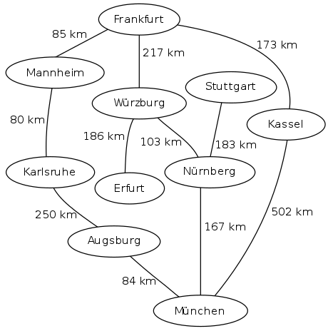

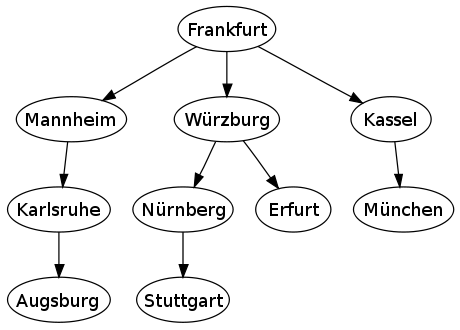

# Example Query

[Court House, Arlington, Virginia](https://en.wikipedia.org/wiki/Court_House,_Arlington,_Virginia) $\to$ [Judiciary Square station](https://en.wikipedia.org/wiki/Judiciary_Square_station)

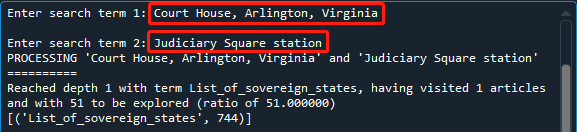

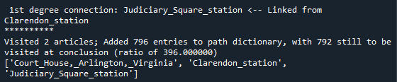

# Linkage in action

Notice the link to the target (destination) is only present within a transcluded `Template`.

[figure not shown]

[figure not shown]

# Some analytics terms, defined

- **Number of links added**: The number of unique links newly added when visiting an article, approximately $|\text{links added}| = |L| - |Q| - |V|$, where $L:=\text{unique links on article}$, $Q:=\{\text{links already in Queue}\}$ and $V:=\{\text{links already Visited}\}$
- **Ratio of links added**, building on the prior term: $\frac{|\text{links added}|}{|\text{unique links on article}|}$
- **Rolling $X$**: the summary statistic of the last $X$ entries in a series

# Initial plotting

Query: Zhongguancun to [Chelsea, Manhattan](https://en.wikipedia.org/wiki/Chelsea,_Manhattan)

OK to only fixate on line styles at relatively few articles…

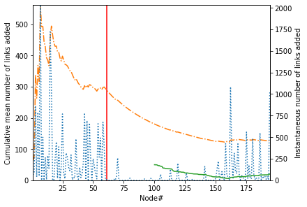

…not so great beyond a thousand articles or so.

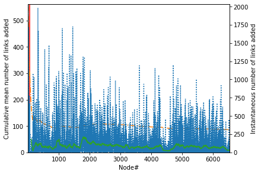

# How do we fix the transparency…?

of the instantaneous series and stop it from crowding out the other two series?

```
line_instant = ax2.plot(x, instant, color='tab:blue', linestyle='dotted',
                        alpha=0.25, label='Instantaneous added')
```

Note the `alpha` and `linestyle` parameters.

Better now:

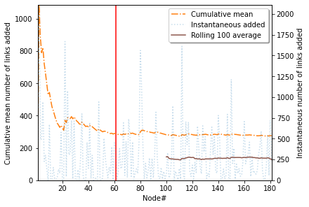

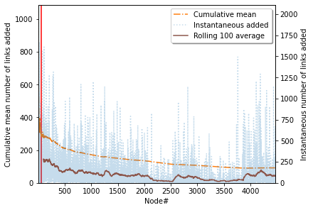

# Mind the asymptote!

Query: [Index of Singapore-related articles](https://en.wikipedia.org/wiki/Index_of_Singapore-related_articles) to [Orellana Province](https://en.wikipedia.org/wiki/Orellana_Province)

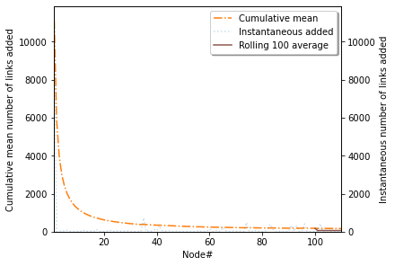

But bunched up all together when completing the run!

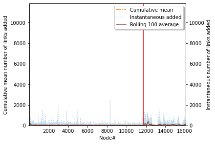

# Conditional log-scale

The basic command is:

```
ax.set_yscale('log')
```

The variable `SWITCH_TO_LOG` is defined as $\text{SWITCH_TO_LOG} := 10^{1.5}=10\sqrt{10} \sim 31.6228$.

```
large_first = max(mean_added) / mean_added[-1] > SWITCH_TO_LOG
if large_first:
    ax.set_yscale('log')
    ax.set_ylim([1, max(mean_added)])
```

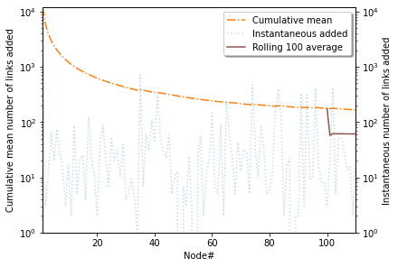

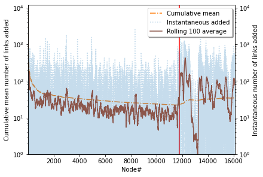

# How does the median ratio behave?

Query: Oakland (Pittsburgh) to [Huangpu District, Shanghai](https://en.wikipedia.org/wiki/Huangpu_District,_Shanghai)

Notice the similarly shaped regions below?

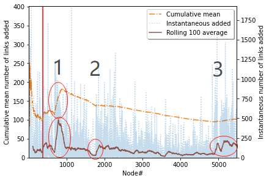

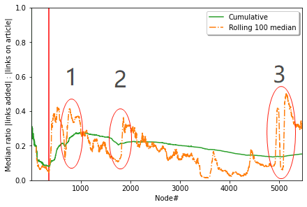

# Correlation

Note: Negative correlations are more likely to occur with only a few dozen articles

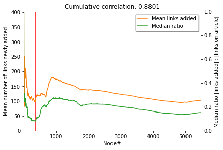

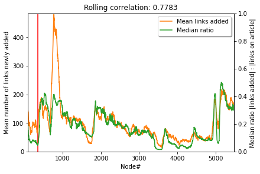

# Thank you

[Link to repository](https://github.com/FAE-Sonata/Wikipath)